# Customer LifeTime Value Prediction

# Team 7

- Amal, Jerome, Brinda, Akhil, Nancy, Tonmoy

What is Customer Lifetime Value Prediction?

Customer lifetime value (CLV or customer LTV) is the predicted sum total of all future revenues (or profits) that a particular customer will generate for a business. It can also be described as a measure of a customer’s total worth to a business over the entire time period of the customer-business relationship. By developing strategies to reduce client churn, policy term businesses can increase the overall CLV of its clients. Higher retention also leads to lower costs and better profit margins as retaining existing customers often costs less than acquiring new ones. Using accurate estimates of CLV as the basis for marketing decisions will maximize the company’s revenues (or profits).

CLV = ((Average Sales * Purchase Frequency)/Churn)*Profit Margin.

Where, Average Sales = (Total Sales)/(Total no. of orders)

Purchase Frequency = (Total no. of orders)/(Total unique customers)

Retention Rate: (Total no. of orders greater than 1)/(Total unique customers)

Churn = 1-Retention Rate

Profit Margin= Based on Business Context.

Top 6 observations of the dataset

```
##   Customer      State Customer.Lifetime.Value Response Coverage Education
## 1  BU79786 Washington                2763.519       No    Basic  Bachelor
## 2  QZ44356    Arizona                6979.536       No Extended  Bachelor
## 3  AI49188     Nevada               12887.432       No  Premium  Bachelor
## 4  WW63253 California                7645.862       No    Basic  Bachelor
## 5  HB64268 Washington                2813.693       No    Basic  Bachelor
## 6  OC83172     Oregon                8256.298      Yes    Basic  Bachelor
##   Effective.To.Date EmploymentStatus Gender Income Location.Code Marital.Status
## 1           2/24/11         Employed      F  56274      Suburban        Married
## 2           1/31/11       Unemployed      F      0      Suburban         Single
## 3           2/19/11         Employed      F  48767      Suburban        Married
## 4           1/20/11       Unemployed      M      0      Suburban        Married
## 5        02-03-2011         Employed      M  43836         Rural         Single
## 6           1/25/11         Employed      F  62902         Rural        Married
##   Monthly.Premium.Auto Months.Since.Last.Claim Months.Since.Policy.Inception
```

[output cut: 20 more lines]

Structure of the Dataset:

```
## [1] 9134   24
```

We can conclude that our dataset has no null values present in it. The graph also concludes the same.

```
##                               na_counts
## Customer                              0
## State                                 0
## Customer.Lifetime.Value               0
## Response                              0
## Coverage                              0
## Education                             0
## Effective.To.Date                     0
## EmploymentStatus                      0
## Gender                                0
## Income                                0
## Location.Code                         0
## Marital.Status                        0
## Monthly.Premium.Auto                  0
## Months.Since.Last.Claim               0
## Months.Since.Policy.Inception         0
## Number.of.Open.Complaints             0
## Number.of.Policies                    0
## Policy.Type                           0
## Policy                                0
## Renew.Offer.Type                      0
## Sales.Channel                         0
## Total.Claim.Amount                    0
## Vehicle.Class                         0
## Vehicle.Size                          0
```

[output not shown]

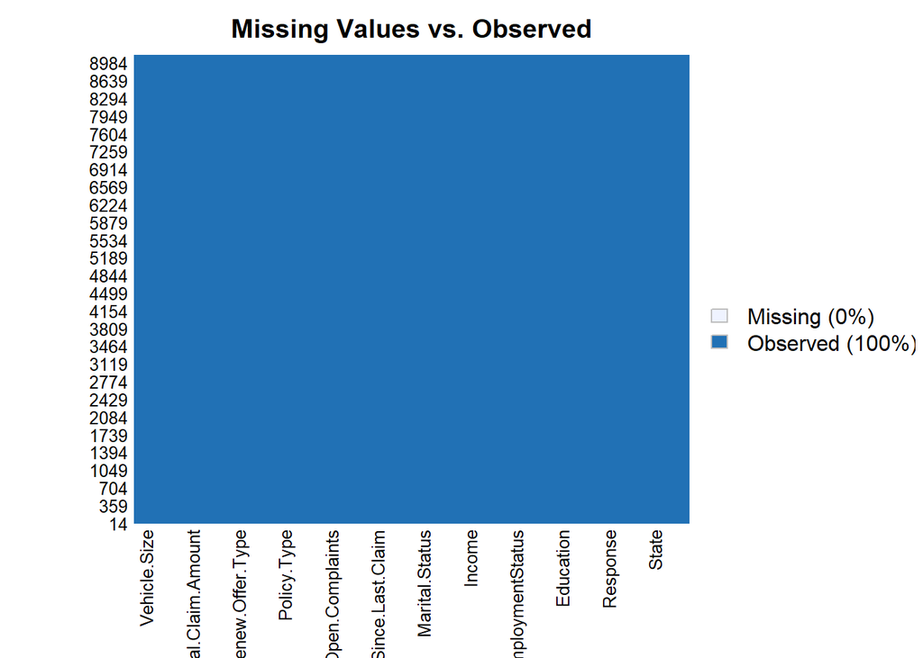

# EDA

A series of statistical tests will be done to understand the relationships between the features, but they are only supportive and not conclusive. The main insights come from the EDA

### Customer

There are 9134 rows in the dataset and each of those rows correspond to a unique customer Id.

```
## [1] 9134
```

### Customer Lifetime Value

```
##   Customer      State Customer.Lifetime.Value Response Coverage Education
## 1  WF51811    Arizona                2719.507      Yes    Basic   College
## 2  LS59637    Arizona                2719.507      Yes    Basic   College
## 3  YC69616    Arizona                2719.507      Yes    Basic   College
## 4  SC40169     Oregon                2719.507      Yes    Basic   College
## 5  ST65635    Arizona                2719.507      Yes    Basic   College
## 6  EI58541 Washington                2719.507      Yes    Basic   College
##   Effective.To.Date EmploymentStatus Gender Income Location.Code Marital.Status
## 1           1/24/11          Retired      F  14030      Suburban        Married
## 2           1/24/11          Retired      F  14030      Suburban        Married
## 3           1/24/11          Retired      F  14030      Suburban        Married
## 4           1/24/11          Retired      F  14030      Suburban        Married
## 5           1/24/11          Retired      F  14030      Suburban        Married
## 6           1/24/11          Retired      F  14030      Suburban        Married
##   Monthly.Premium.Auto Months.Since.Last.Claim Months.Since.Policy.Inception
```

[output cut: 20 more lines]

As it can be seen, the customers are essentially the exact same in all columns but State, Policy type and Policy and their id. This pattern is followed for all the rows that share the same CLV. If the State values were erroneously entered, these could all be the same customer that bought different policies at the same time, which would imply that the CLV is independent of these values for a given person. Will need to investigate furthur. Below is the distribution of CLV. It’s a highly positively skewed distribution, hence the following analyses will use the log transformed clv instead only for visualization. For the tests we use the original column.

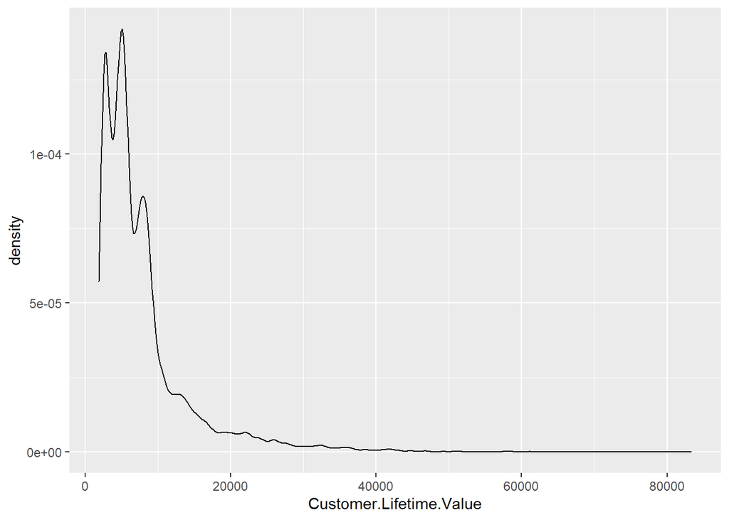

The data seems to consist of three clusters of points each having distinct CLV distributions. Divided about the median, all points having greater CLV seem to follow a positively skewed distribution and all points below the median seem to follow two different approximately normal distributions. These can be seen below for the CLV ranges of 1000-3000, 3000-5780 and 5780-90000

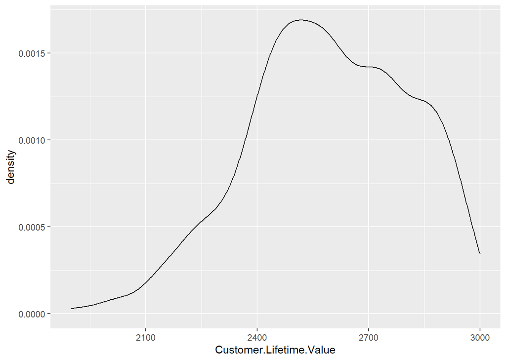

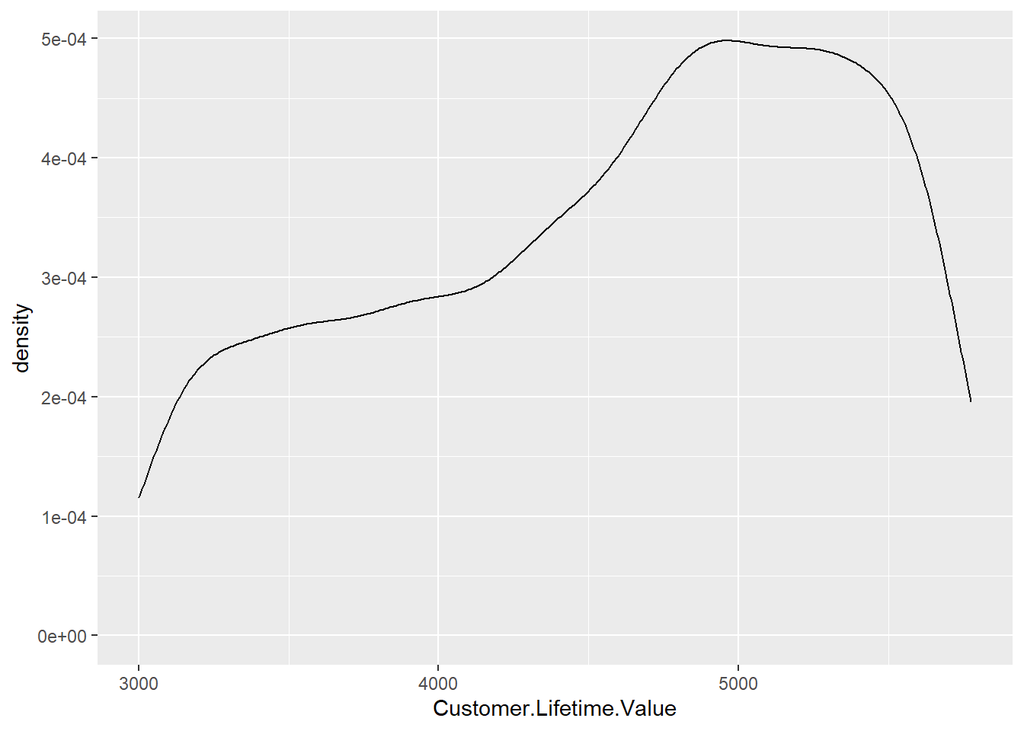

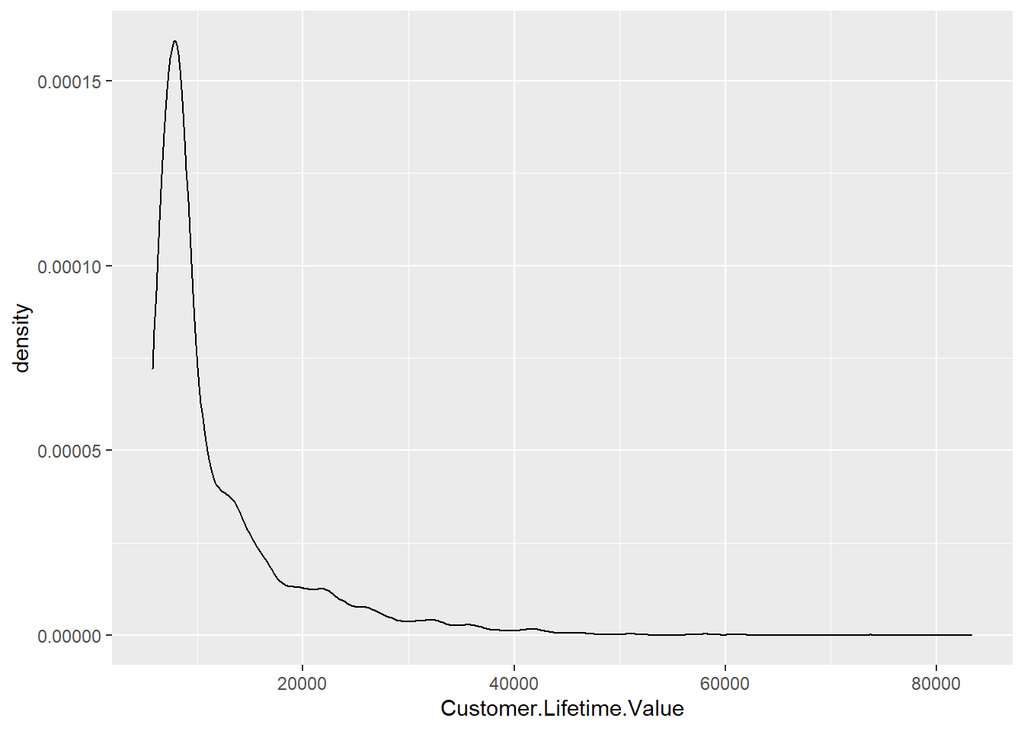

### Response  
This is the column that records the response of the customers to a renewal offer. This can be treated as a nominal variable.

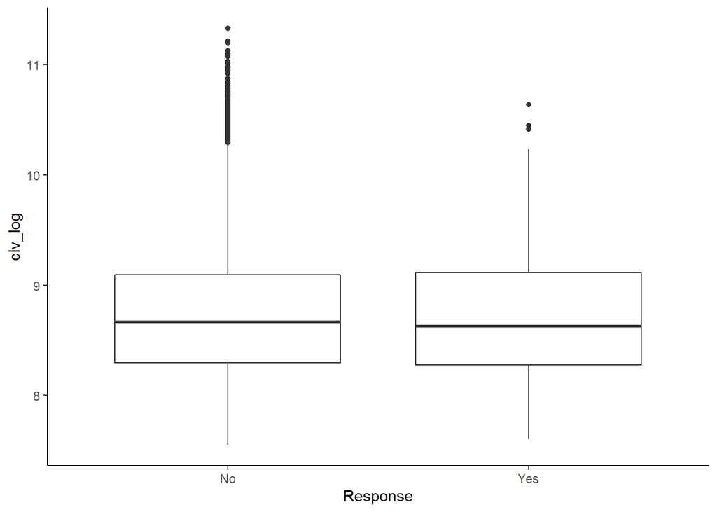

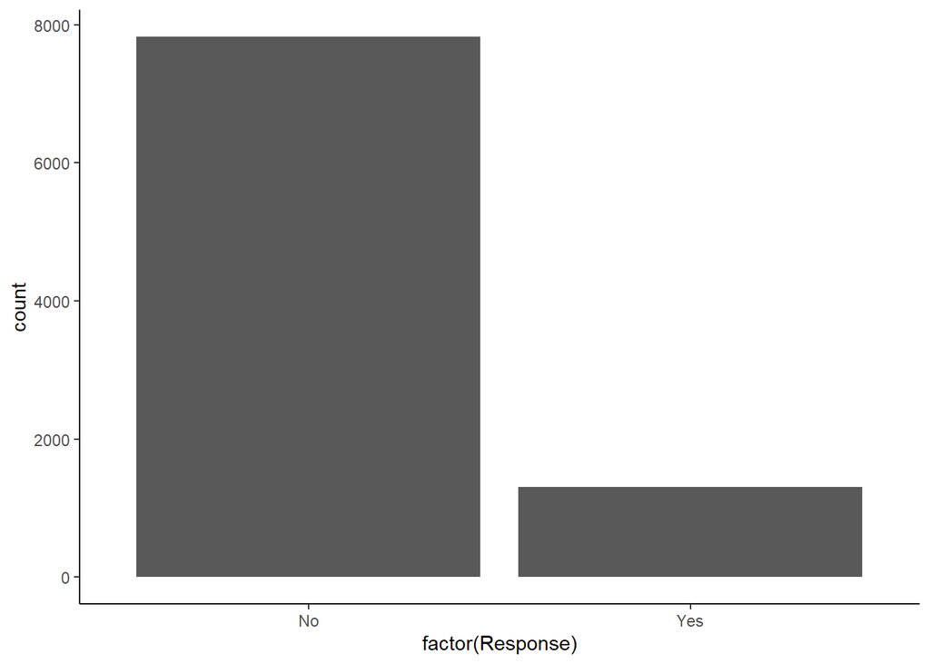

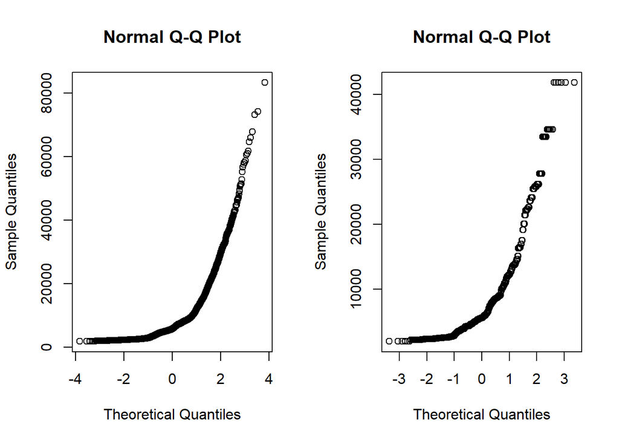

```
## # A tibble: 2 x 5
##   Response count  mean    sd median
##   <chr>    <int> <dbl> <dbl>  <dbl>
## 1 No        7826 8030. 6969.  5814.
## 2 Yes       1308 7855. 6256.  5596.
```

Clearly, the assumption of normality is violated. Also since the sample sizes are not approximately equal, the t statistic will be skewed in the same direction as shown by the smaller sample. Will need a non-parametric test. Therefore proceeding with Mann-Whitney U test.

```
##
##  Wilcoxon rank sum test with continuity correction
##
## data:  Customer.Lifetime.Value by Response
## W = 5175420, p-value = 0.5169
## alternative hypothesis: true location shift is not equal to 0
```

From above we can conclude that at 0.05 level of significance (The same level will be used in all the future tests), we fail to reject the null hypothesis that there is no statistically significant difference between the levels of response and therefore they are drawn from the same population. Hence knowing the response of a customer will not provide any new information on the values of the target. Moving onto the next variable,

### State

State is a nominal variable and consists of the west coast states in the U.S., California, Oregon, Arizona, Nevada and Washington.

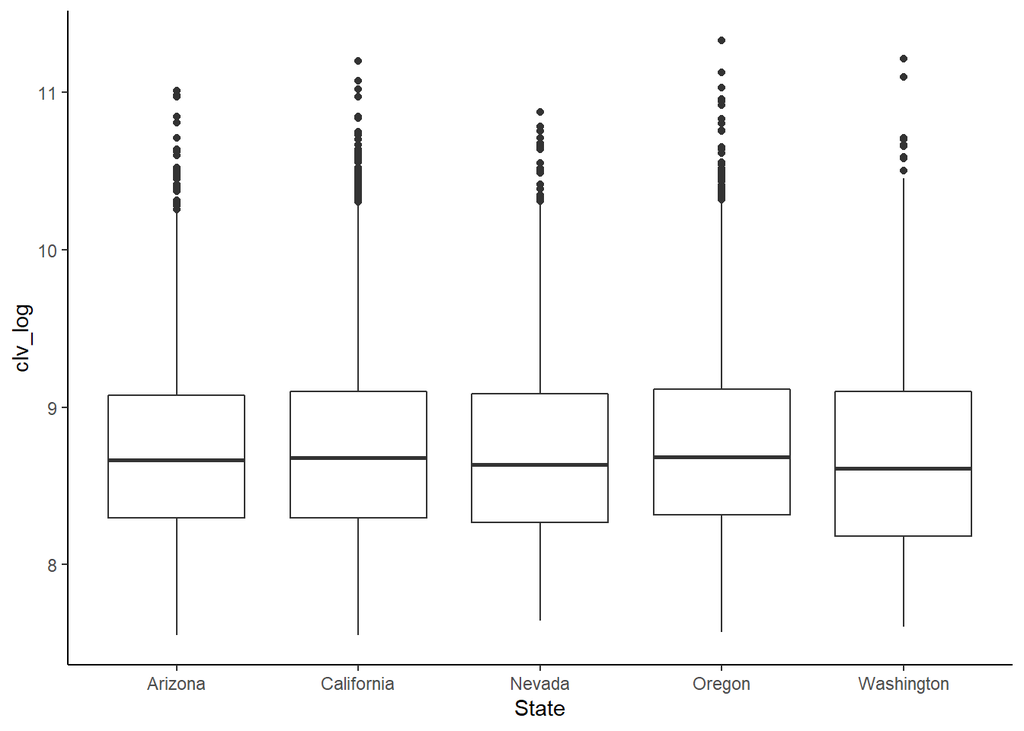

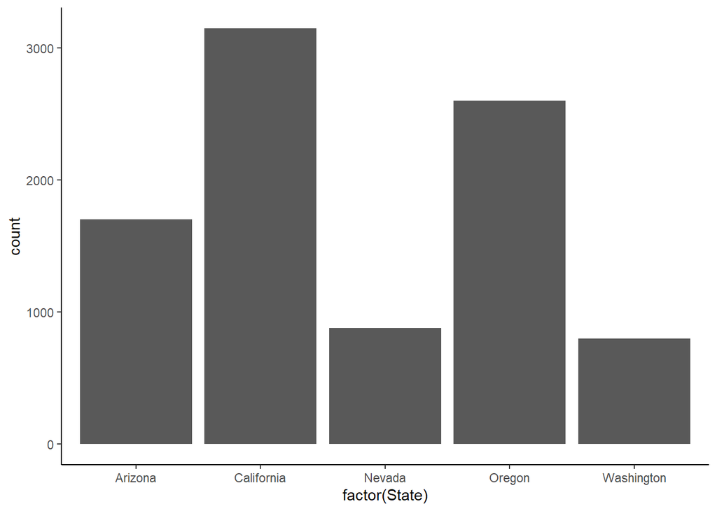

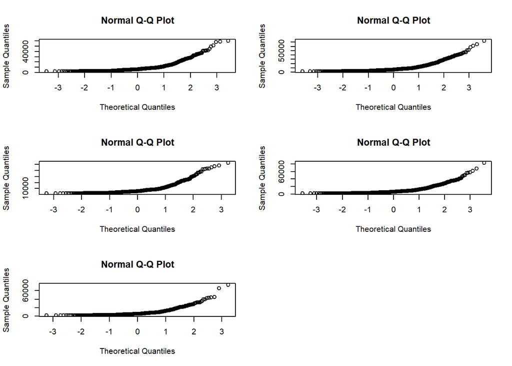

```
## # A tibble: 5 x 5
##   State      count  mean    sd median
##   <chr>      <int> <dbl> <dbl>  <dbl>
## 1 Arizona     1703 7861. 6703.  5791.
## 2 California  3150 8004. 6726.  5871.
## 3 Nevada       882 8057. 7092.  5630.
## 4 Oregon      2601 8078. 6909.  5906.
## 5 Washington   798 8021. 7410.  5502.
```

Normality is violated. Therefore we need to use the non-parametric equivalent of one-way ANOVA, the Kruskal-Wallis test. One of the assumptions of this test is homoscedasticity of the groups. In order to verify this, we’ll need to use Levene’s test:

```
## Levene's Test for Homogeneity of Variance (center = median)
##         Df F value Pr(>F)
## group    4  0.6421 0.6324
##       9129
```

Thus from the p-value above we conclude that at a significance level of 0.05, we fail to reject the null hypothesis that all population variances are equal. This is also corroborated by the variances of the levels seen above. Having proved that the levels are homoscedastic we now move onto Kruskal-Wallis test:

```
##
##  Kruskal-Wallis rank sum test
##
## data:  Customer.Lifetime.Value by State
## Kruskal-Wallis chi-squared = 5.0721, df = 4, p-value = 0.28
```

As the p-value is greater than the significance level, we can thus conclude that there is no significant difference between the states, in terms of the CLV.

### Coverage

About 61% of the cutomers chose the basic coverage while only 9% chose the premium coverage type. Of those customers that chose the premium coverage type, 73% had a CLV greater than the median CLV of 5780. Of those cutomers that chose the basic coverage type, 40% had a CLV greater than the median CLV. Finally of those with extended coverage type, about 62% have a value greater than the CLV median. Coverage could be used as an ordinal variable with the order of: Basic<Extended<Premium

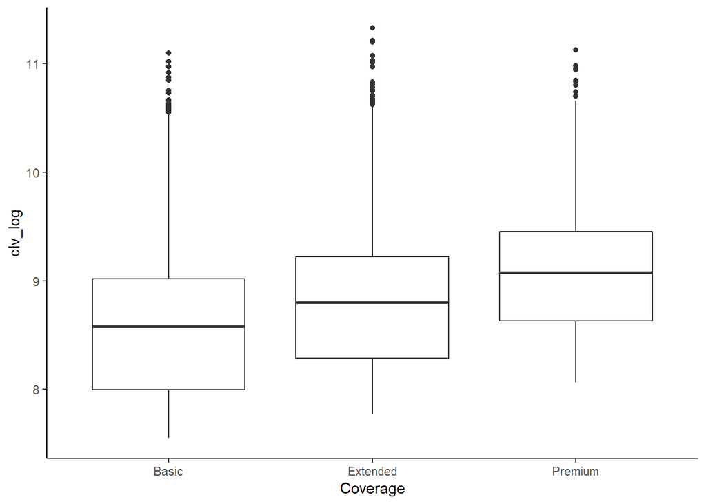

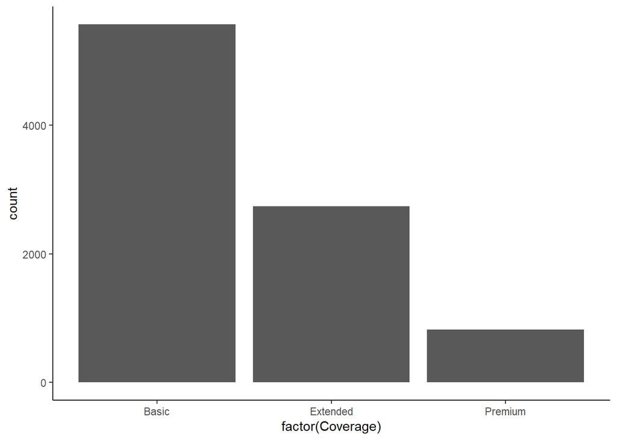

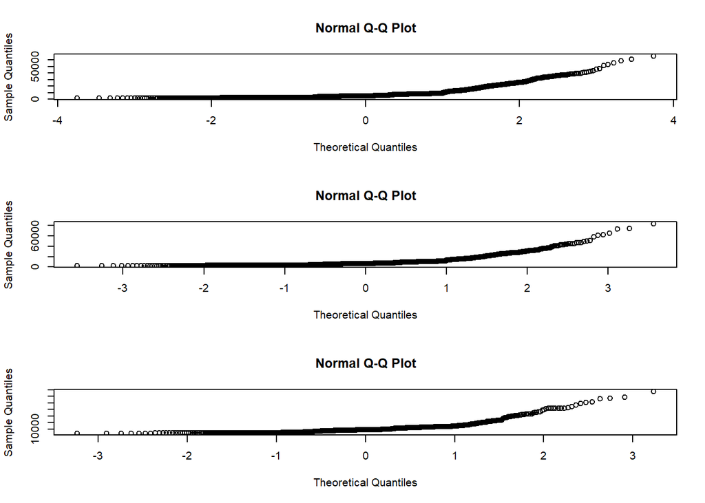

```
## # A tibble: 3 x 5
##   Coverage count   mean    sd median
##   <chr>    <int>  <dbl> <dbl>  <dbl>
## 1 Basic     5568  7191. 6142.  5297.
## 2 Extended  2742  8790. 7427.  6627.
## 3 Premium    824 10896. 8371.  8718.
```

Again, as the assumption of normality is violated, and since there are three groups, Kruskal-Wallis test must be employed. Checking for equality of variances:

```
## Levene's Test for Homogeneity of Variance (center = median)
##         Df F value    Pr(>F)
## group    2  28.795 3.417e-13 ***
##       9131
## ---
## Signif. codes:  0 '***' 0.001 '**' 0.01 '*' 0.05 '.' 0.1 ' ' 1
```

This means that the null hypothesis of the equality of variances is rejected at the significance level. This being an assumption of Kruskal-Wallis, we won’t be able to use it.

### Education

This is education recieved by the customers, which may be condsidered as a nominal variable.

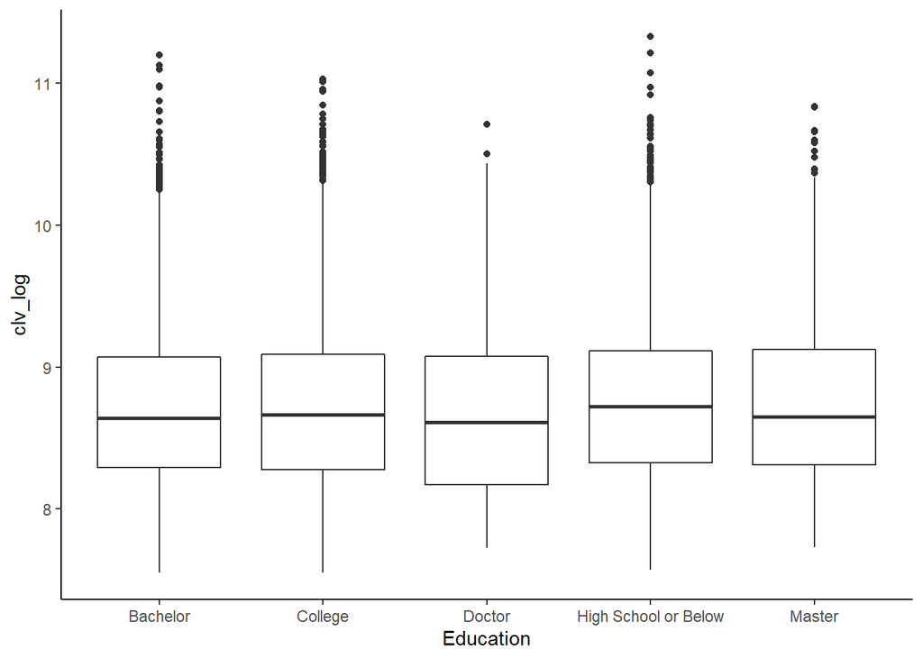

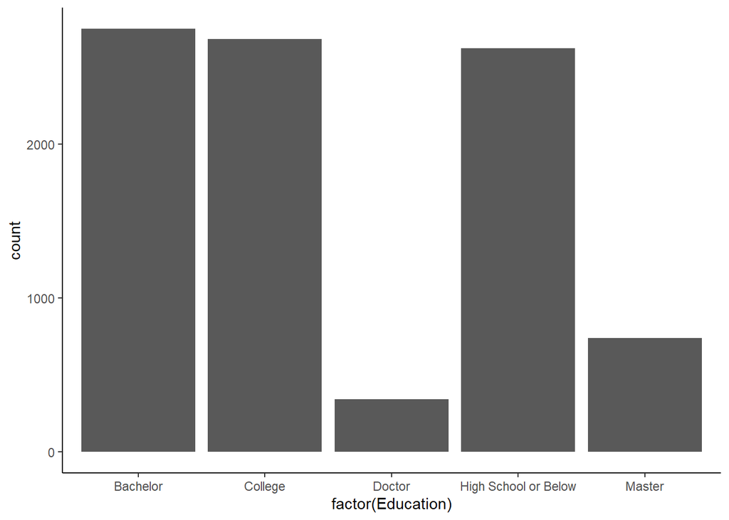

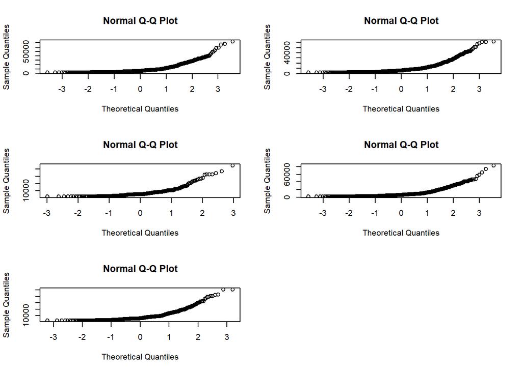

```
## # A tibble: 5 x 5
##   Education            count  mean    sd median
##   <chr>                <int> <dbl> <dbl>  <dbl>
## 1 Bachelor              2748 7873. 6759.  5642.
## 2 College               2681 7851. 6687.  5792.
## 3 Doctor                 342 7520. 6268.  5494.
## 4 High School or Below  2622 8297. 7221.  6130.
## 5 Master                 741 8243. 6909.  5718.
```

Doing Levene’s test:

```
## Levene's Test for Homogeneity of Variance (center = median)
##         Df F value Pr(>F)
## group    4   1.442 0.2172
##       9129
```

The population variances are the same. Kruskal-Wallis test:

```
##
##  Kruskal-Wallis rank sum test
##
## data:  Customer.Lifetime.Value by Education
## Kruskal-Wallis chi-squared = 12.234, df = 4, p-value = 0.01569
```

Therefore there appears to be a difference in the CLV of different education groups. However, by how much the difference exists is also important, aka the effect size. The difference in this case of the means is at most 776. A small difference as this, isn’t that important to a bank however.

### Effective To Date

The maximun and the minimum dates in this column are as below. This means that the maturity date of all the policies in the dataset is only between January and Feburary of 2011. It was also found that CLV is uniformly distributed across all days. Which is expected. This column however, won’t provide any information to our models.

```
## [[1]]
## [1] "01-01-2011"
##
## [[2]]
## [1] "2/28/11"
```

### EmploymentStatus

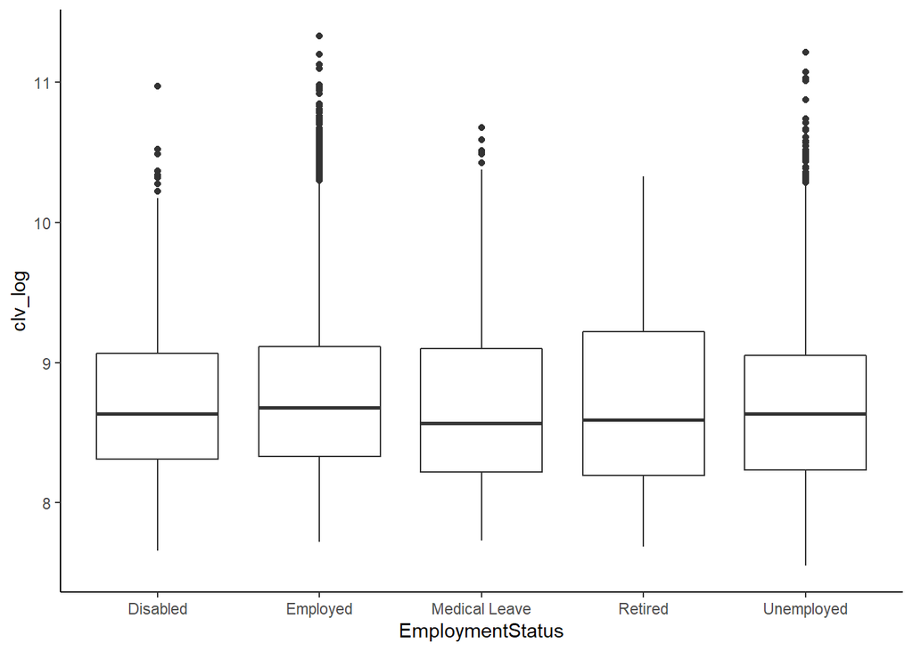

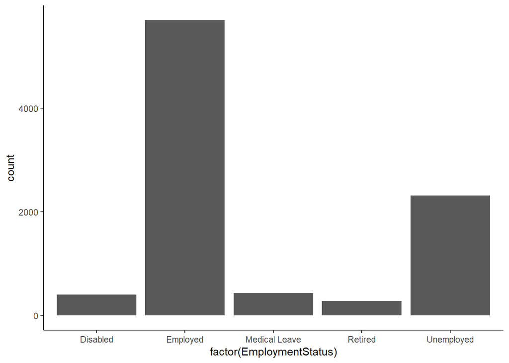

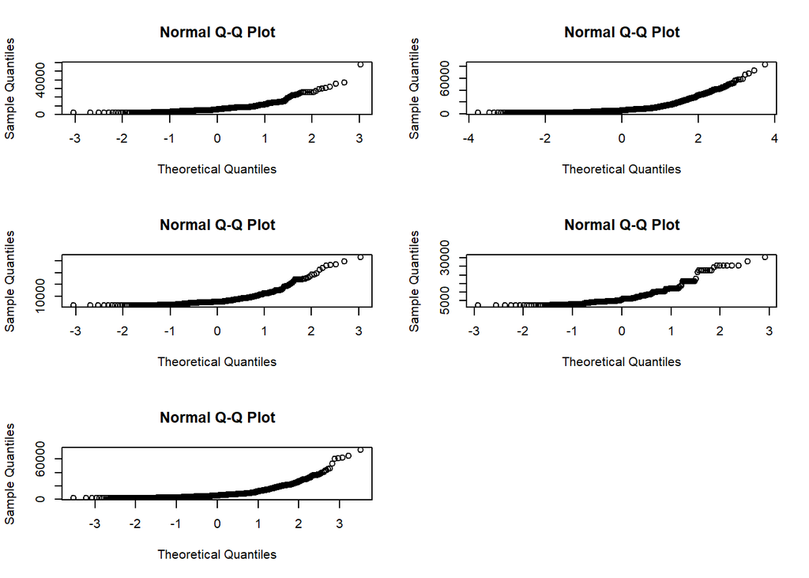

```
## # A tibble: 5 x 5
##   EmploymentStatus count  mean    sd median
##   <chr>            <int> <dbl> <dbl>  <dbl>
## 1 Disabled           405 7848. 6443.  5623.
## 2 Employed          5698 8219. 7067.  5864.
## 3 Medical Leave      432 7642. 6501.  5259.
## 4 Retired            282 7488. 5761.  5395.
## 5 Unemployed        2317 7636. 6624.  5620.
```

Levene’s test:

```
## Levene's Test for Homogeneity of Variance (center = median)
##         Df F value Pr(>F)
## group    4  0.7071  0.587
##       9129
```

Hence equal variances Kruskal-Wallis:

```
##
##  Kruskal-Wallis rank sum test
##
## data:  Customer.Lifetime.Value by EmploymentStatus
## Kruskal-Wallis chi-squared = 42.562, df = 4, p-value = 1.276e-08
```

Therefore there is a difference between the groups.

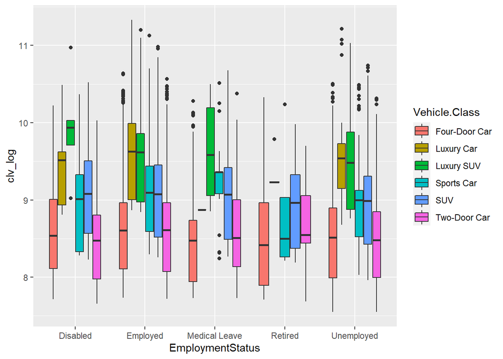

### Gender

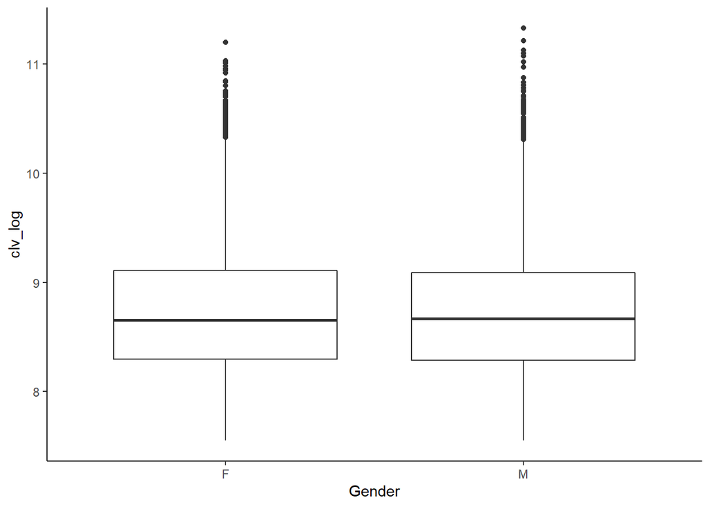

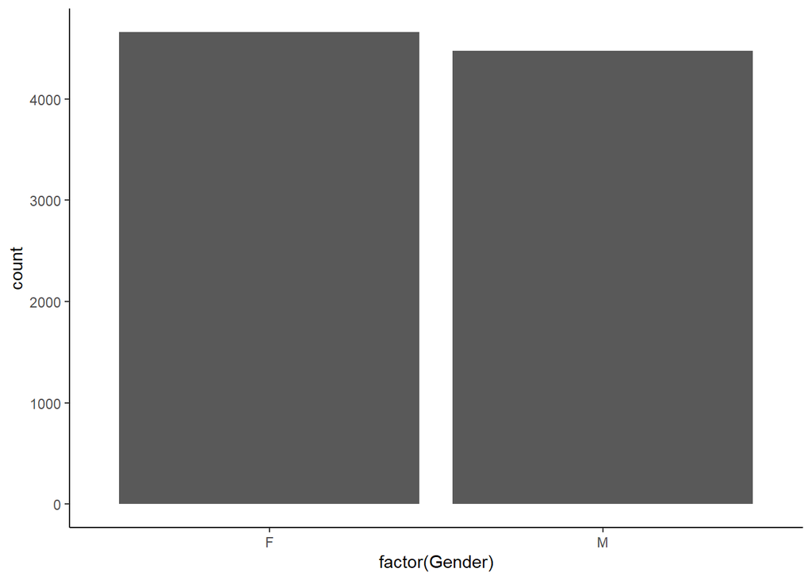

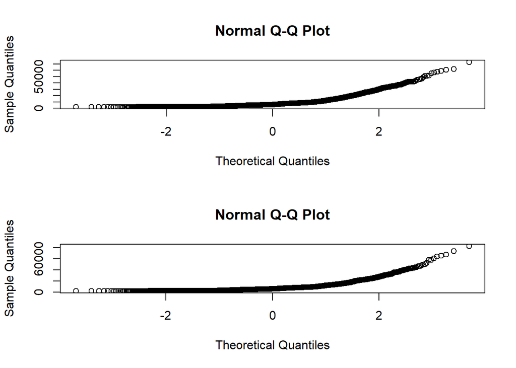

```
## # A tibble: 2 x 5
##   Gender count  mean    sd median
##   <chr>  <int> <dbl> <dbl>  <dbl>
## 1 F       4658 8097. 6956.  5742.
## 2 M       4476 7910. 6781.  5815.
```

Mann-Whitney test:

[output not shown]

The CLV for both male and female groups are similarly distributed.

### Income

As shown, it appears that unemployed people have a wide range of CLV, which is counterintuitive. In fact the distributions of both the groups are similar.

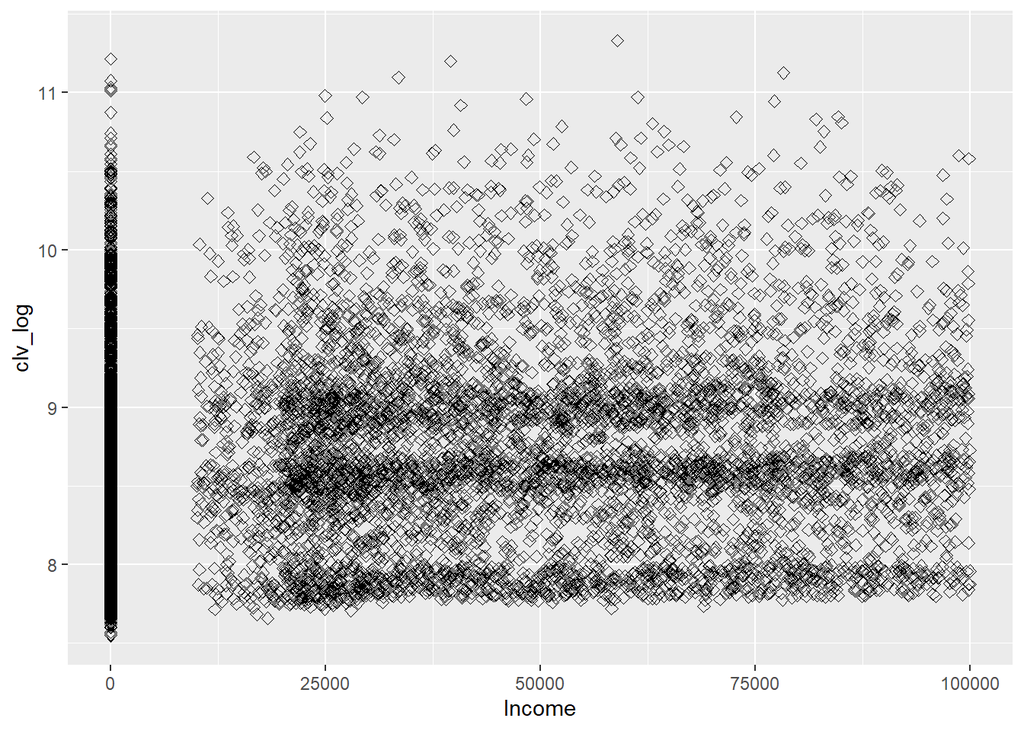

The majority proportions and the medians were found of the no income group. Some of them are: - 57% are single  
- 60% opted basic coverage  
- 34% went to high school or below  
- 50% were male  
- 524.836298 was the median total claim amount  
- 91% responded no to a renewal offer  
- 91% reside in a suburban area  
- 79% had zero unsolved complaints  
- 50% insured a four-door car.  
In the group that had a non-zero income, all the above proportions and the medians are exactly similar expect that 53% resided in a suburban area and the median total claim amount was 340.8

### Location Code

Location code, like most of the above nominal columns is equally divided about the median of CLV for all its levels.

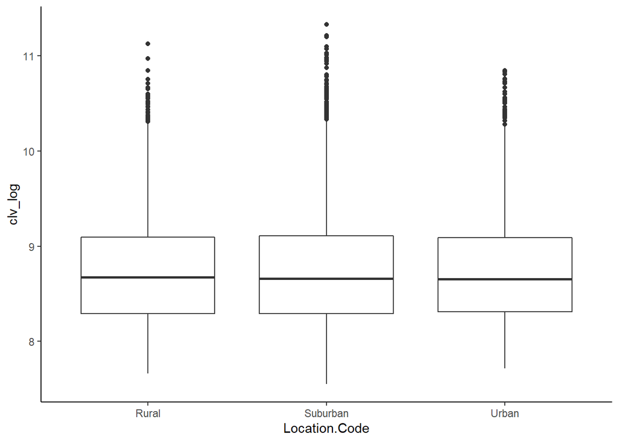

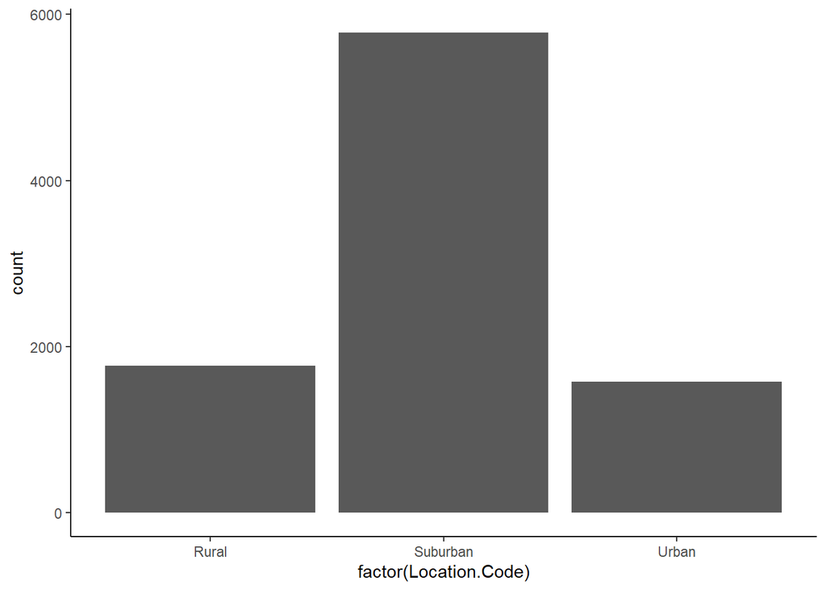

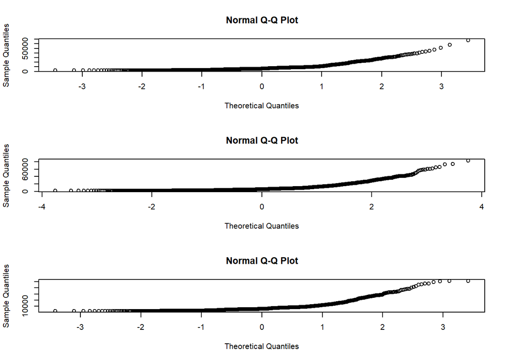

```
## # A tibble: 3 x 5
##   Location.Code count  mean    sd median
##   <chr>         <int> <dbl> <dbl>  <dbl>
## 1 Rural          1773 7954. 6595.  5847.
## 2 Suburban       5779 8004. 6964.  5771.
## 3 Urban          1582 8064. 6836.  5744.
```

```
## Levene's Test for Homogeneity of Variance (center = median)
##         Df F value Pr(>F)
## group    2  0.3158 0.7292
##       9131
```

```
##
##  Kruskal-Wallis rank sum test
##
## data:  Customer.Lifetime.Value by Location.Code
## Kruskal-Wallis chi-squared = 2.4638, df = 2, p-value = 0.2917
```

Location code has no effect on the CLV.

### Marital Status

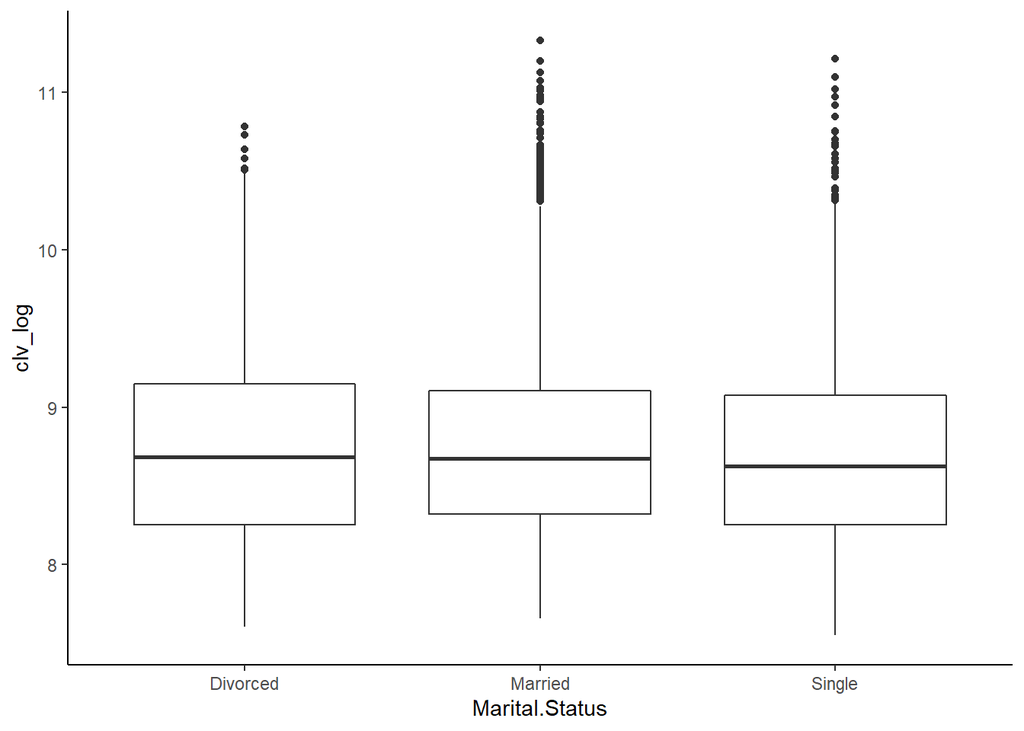

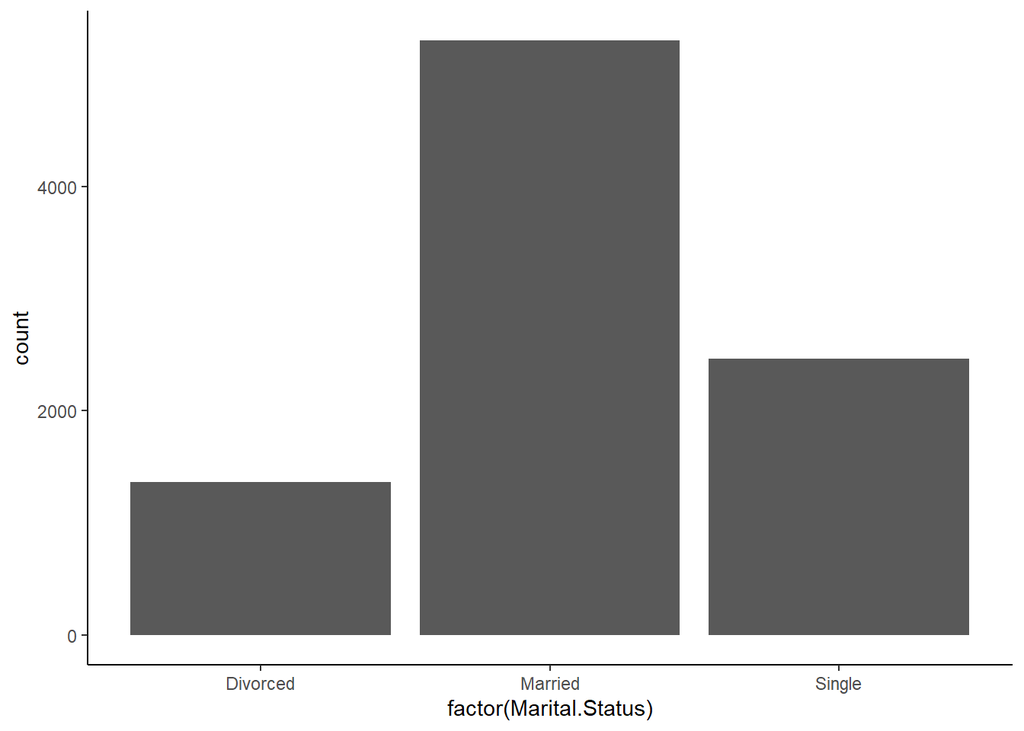

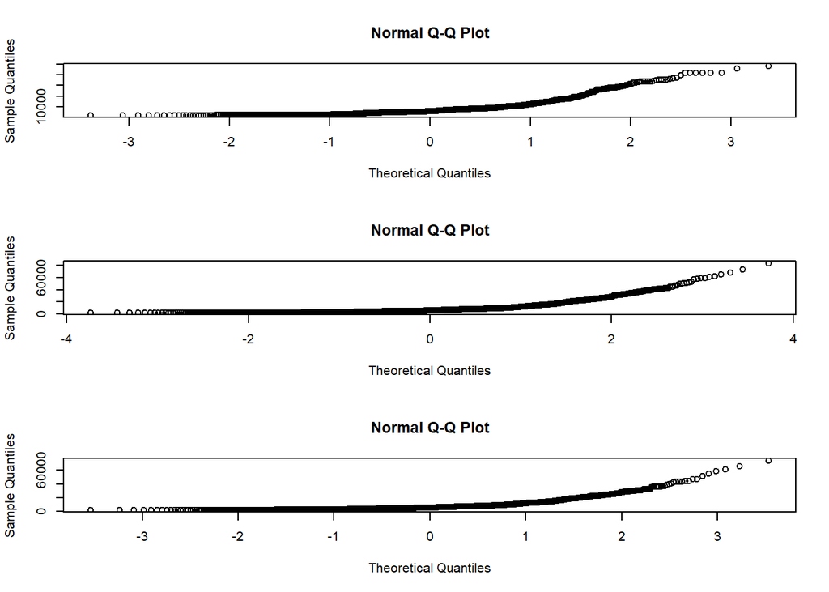

```
## # A tibble: 3 x 5
##   Marital.Status count  mean    sd median
##   <chr>          <int> <dbl> <dbl>  <dbl>
## 1 Divorced        1369 8241. 6985.  5899.
## 2 Married         5298 8079. 6903.  5838.
## 3 Single          2467 7715. 6731.  5569.
```

```
## Levene's Test for Homogeneity of Variance (center = median)
##         Df F value Pr(>F)
## group    2  1.7277 0.1777
##       9131
```

```
##
##  Kruskal-Wallis rank sum test
##
## data:  Customer.Lifetime.Value by Marital.Status
## Kruskal-Wallis chi-squared = 20.896, df = 2, p-value = 2.901e-05
```

Therefore the levels are from different populations.